# Regularized Regression Life Insurance Example

Shane Kennedy FSAI, FIA

last updated: 2021-04-08

# 1 Introduction

## 1.1 Objectives

- Fit a regularized regression model to a subset of the data set (training set) using LASSO with logistic regresssion
- Use the model to predict claims incidence rates and expected payouts on the hold out data (test set)

Many of the techniques applied in this document are described in ‘Introduction to statistical learning with applications in R’

## 1.2 Simulated data

Overview:

- A data set was simulated representing a block of insured lives for annually renewable group corporate life insurance business
- Member and claims data is provided from 2000 up to 2020
- Some simplifications are made e.g. assume that no members leave schemes during the year
- For illustrative purposes unknown continuous variables are added to the data set which have some correlation with other known variables.

Variable definitions:

- Age: Exact age of insured life at beginning of exposure year
- Sum Assured: Insurance coverage equal to two times salary
- Salary: Insured life’s salary at beginning of exposure year
- Gender: M = Male, F = Female
- Occ: Occupation class. 1 = white collar/office workers, 2 = 50% office work/50% manual work, 3 = blue collar/manual work
- occ.desc: description of occupations
- Claim: Y = Claim occured during exposure year resulting in a payout of sum assured
- Location: Three locations of coverage (site 1, site 2, site 3)
- Smoker: 0 = non smoker, 1 = smoker
- Compulsory: 0 = not compulsory for employee to become member of scheme, 1 = compulsory for employee to become member of scheme
- yrs_service: number of years service since joining the company
- vo2max: vo2max recorded for employee when they joined the company
- bmi: body max index recorded for employee when they joined the company
- var1 - var5: unknown continuous variables provided

# 2 High level look at the data

## 2.1 Install and load packages

```r
start_time=Sys.time()

install_packages <- c("dplyr","glmnet","MASS","matrixcalc","corpcor","psych","data.table")
not_installed <- install_packages[which(!(install_packages %in% installed.packages()[,1]))]

if (length(not_installed > 0)){
  install.packages(not_installed)
}

library(dplyr)
library(glmnet)
library(MASS)
library(matrixcalc)
library(corpcor)
library(psych)
```

## 2.2 Summary of data

```r
wd<-getwd()

source(paste0(wd,"/Simulate_data.R"))

life_insurance_data<-data.table::fread(paste0(wd,"/Life_Insurance_data.csv"))

str(life_insurance_data)
```

```
## Classes 'data.table' and 'data.frame':   118786 obs. of  20 variables:
##  $ V1           : int  1 2 3 4 5 6 7 8 9 10 ...
##  $ age          : num  25.8 44.3 36.6 33.9 42.1 ...
##  $ sum.assured  : num  27000 141000 74000 50000 109000 7000 84000 27000 68000 37000 ...
##  $ salary       : num  13500 70500 37000 25000 54500 3500 42000 13500 34000 18500 ...
##  $ gender       : chr  "F" "M" "M" "M" ...
##  $ occ          : int  1 1 2 1 1 3 3 3 2 3 ...
##  $ claim        : chr  "N" "Y" "N" "N" ...
##  $ location     : chr  "site2" "site3" "site2" "site2" ...
##  $ smoker_status: int  0 1 0 0 0 0 1 0 0 0 ...
##  $ compulsory   : int  1 0 1 0 1 1 0 1 1 1 ...
##  $ yrs_service  : num  7.4 12.94 7.74 10.53 6.84 ...
##  $ vo2max       : num  33 25.3 28.8 25.5 28.2 ...
##  $ bmi          : num  26.5 29.1 27.8 27.4 28.7 ...
##  $ var1         : num  19.72 7.45 13.22 7.89 12.36 ...
##  $ var2         : num  20.6 20.5 20.9 20 20 ...
##  $ var3         : num  360 358 359 358 359 ...
##  $ var4         : num  9751 9752 9752 9751 9748 ...
##  $ var5         : num  57.3 72.4 58.3 66.2 55.6 ...
##  $ occ.desc     : chr  "job1" "job1" "job2" "job1" ...
##  $ exposure_year: int  2000 2000 2000 2000 2000 2000 2000 2000 2000 2000 ...
##  - attr(*, ".internal.selfref")=<externalptr>
```

```r
summary(life_insurance_data)
```

```
##        V1              age         sum.assured          salary
##  Min.   :     1   Min.   :17.01   Min.   :   2000   Min.   :  1000
##  1st Qu.: 29697   1st Qu.:35.72   1st Qu.:  36000   1st Qu.: 18000
##  Median : 59394   Median :39.74   Median :  60000   Median : 30000
##  Mean   : 59394   Mean   :40.05   Mean   :  80791   Mean   : 40396
##  3rd Qu.: 89090   3rd Qu.:44.05   3rd Qu.: 101000   3rd Qu.: 50500
##  Max.   :118786   Max.   :77.49   Max.   :1721000   Max.   :860500
##     gender               occ           claim             location
##  Length:118786      Min.   :1.000   Length:118786      Length:118786
##  Class :character   1st Qu.:1.000   Class :character   Class :character
##  Mode  :character   Median :2.000   Mode  :character   Mode  :character
##                     Mean   :1.938
##                     3rd Qu.:3.000
##                     Max.   :3.000
##  smoker_status      compulsory      yrs_service         vo2max
##  Min.   :0.0000   Min.   :0.0000   Min.   : 2.800   Min.   :22.90
##  1st Qu.:0.0000   1st Qu.:0.0000   1st Qu.: 8.343   1st Qu.:27.28
##  Median :0.0000   Median :1.0000   Median : 9.821   Median :28.77
##  Mean   :0.2613   Mean   :0.5907   Mean   :10.019   Mean   :29.05
##  3rd Qu.:1.0000   3rd Qu.:1.0000   3rd Qu.:11.508   3rd Qu.:30.51
##  Max.   :1.0000   Max.   :1.0000   Max.   :25.697   Max.   :44.30
##       bmi             var1             var2            var3
##  Min.   :26.08   Min.   : 2.804   Min.   :20.00   Min.   :357.5
##  1st Qu.:27.64   1st Qu.:10.799   1st Qu.:20.44   1st Qu.:358.7
##  Median :28.27   Median :13.207   Median :20.84   Median :359.0
##  Mean   :28.43   Mean   :13.564   Mean   :21.04   Mean   :359.0
##  3rd Qu.:29.04   3rd Qu.:15.922   3rd Qu.:21.42   3rd Qu.:359.3
##  Max.   :37.54   Max.   :36.077   Max.   :29.34   Max.   :361.8
##       var4           var5          occ.desc         exposure_year
##  Min.   :9744   Min.   : 41.06   Length:118786      Min.   :2000
##  1st Qu.:9750   1st Qu.: 60.09   Class :character   1st Qu.:2012
##  Median :9751   Median : 64.23   Mode  :character   Median :2016
##  Mean   :9751   Mean   : 64.53                      Mean   :2015
##  3rd Qu.:9752   3rd Qu.: 68.72                      3rd Qu.:2019
##  Max.   :9764   Max.   :101.20                      Max.   :2020
```

Here we can see the number of observations and variables.We also begin to develop an understanding of the variable types and distributions.

## 2.3 Some data manipulation

- Remove some unnecessary columns
- Exclude occ and location for now
- Replace characters with numeric for Gender and Claim

```r
life_insurance_data<-life_insurance_data[,-c(1,6,8,19)]

data_adjusted<-life_insurance_data%>%
  mutate(gender=ifelse(life_insurance_data$gender=="M",0,1))%>%
  mutate(claim=ifelse(life_insurance_data$claim=="N",0,1))
```

## 2.4 Look at correlations

```r
mcor<-round(cor(data_adjusted),2)

lower<-mcor
lower[lower.tri(mcor)]<-""
lower<-as.data.frame(lower)
lower
```

|  | age | sum.assured | salary | gender | claim | smoker_status | compulsory | yrs_service | vo2max | bmi | var1 | var2 | var3 | var4 | var5 | exposure_year |
| --- | --- | --- | --- | --- | --- | --- | --- | --- | --- | --- | --- | --- | --- | --- | --- | --- |
| age | 1 | 0.54 | 0.54 | -0.15 | 0.29 | 0.39 | -0.15 | 0.08 | -0.19 | 0.99 | -0.19 | 0.07 | -0.19 | -0.39 | 0.08 | 0 |
| sum.assured |  | 1 | 1 | -0.12 | 0.24 | 0.29 | -0.12 | 0.12 | -0.14 | 0.55 | -0.14 | -0.26 | -0.14 | -0.39 | 0.12 | 0 |
| salary |  |  | 1 | -0.12 | 0.24 | 0.29 | -0.12 | 0.12 | -0.14 | 0.55 | -0.14 | -0.26 | -0.14 | -0.39 | 0.12 | 0 |
| gender |  |  |  | 1 | -0.2 | -0.32 | 0.69 | -0.06 | 0.8 | -0.15 | 0.8 | 0.1 | 0.8 | -0.41 | -0.06 | 0 |
| claim |  |  |  |  | 1 | 0.48 | -0.24 | 0.29 | -0.27 | 0.3 | -0.28 | 0.28 | -0.28 | 0.24 | 0.28 | 0 |
| smoker_status |  |  |  |  |  | 1 | -0.35 | 0.39 | -0.39 | 0.4 | -0.4 | 0.35 | -0.4 | 0.32 | 0.38 | 0 |
| compulsory |  |  |  |  |  |  | 1 | -0.06 | 0.76 | -0.15 | 0.76 | 0.1 | 0.77 | -0.41 | -0.06 | 0 |
| yrs_service |  |  |  |  |  |  |  | 1 | -0.07 | 0.08 | -0.07 | 0.1 | -0.07 | 0.1 | 1 | 0 |
| vo2max |  |  |  |  |  |  |  |  | 1 | -0.19 | 1 | 0.12 | 1 | -0.51 | -0.07 | 0 |
| bmi |  |  |  |  |  |  |  |  |  | 1 | -0.19 | 0.06 | -0.19 | -0.38 | 0.08 | 0 |

[output cut: 6 more lines]

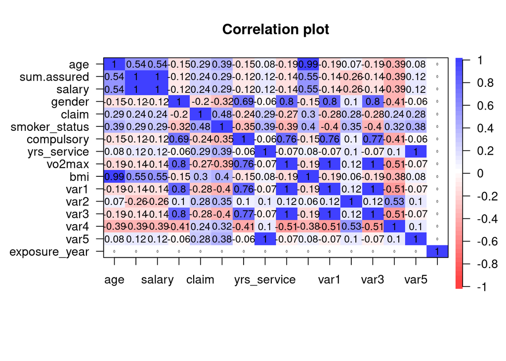

```r
psych::corPlot(data_adjusted)
```

```r
data.table::fwrite(lower,paste0(wd,"/correlations.csv"))
```

Here we can see what variables have high (positive or negative) correlation with the dependent variable (claims). It is clear that claims is highly correlated with smoker status.

We also see that many of the explanatory variables are highly correlated with one another (multicollinearity).For example, sum assured and salary, gender and var1, var3 and var1, vo2max and compulsory, gender and compulsory, age and sum assured/salary.

Multicollinearity can make fitted models more difficult to interpret. This can be mitigated by using regluarlization techniques such as the LASSO.

# 3 Prepare data for modelling

## 3.1 Specify x (explanatory variables) and y (dependent variable)

```r
x=model.matrix(claim ~.,life_insurance_data)
y=life_insurance_data$claim
```

## 3.2 Split data into training and test sets

```r
set.seed(297)
train<-sample (1: nrow(x), floor(nrow(x)*0.8))
test<-(-train)
y_test<-y[test]
```

Here we are randomly splitting the data into training and test sets. A common split is 80/20. It is also common to split the training set even further into training and validation (again using 80/20 is common) where the validation set is used to tune parameters. For simplicity I have not created a validation set here.

# 4 Fit regularized regression model

## 4.1 Use cross validation to choose lambda

- alpha = 1 indicates LASSO
- binomial family indicates logistic regression
- type.measure deviance used as the cost function

Plot includes the cross-validation curve (red dotted line), and upper and lower standard deviation curves along the λ sequence (error bars). Two selected λ’s are indicated by the vertical dotted lines (see below).

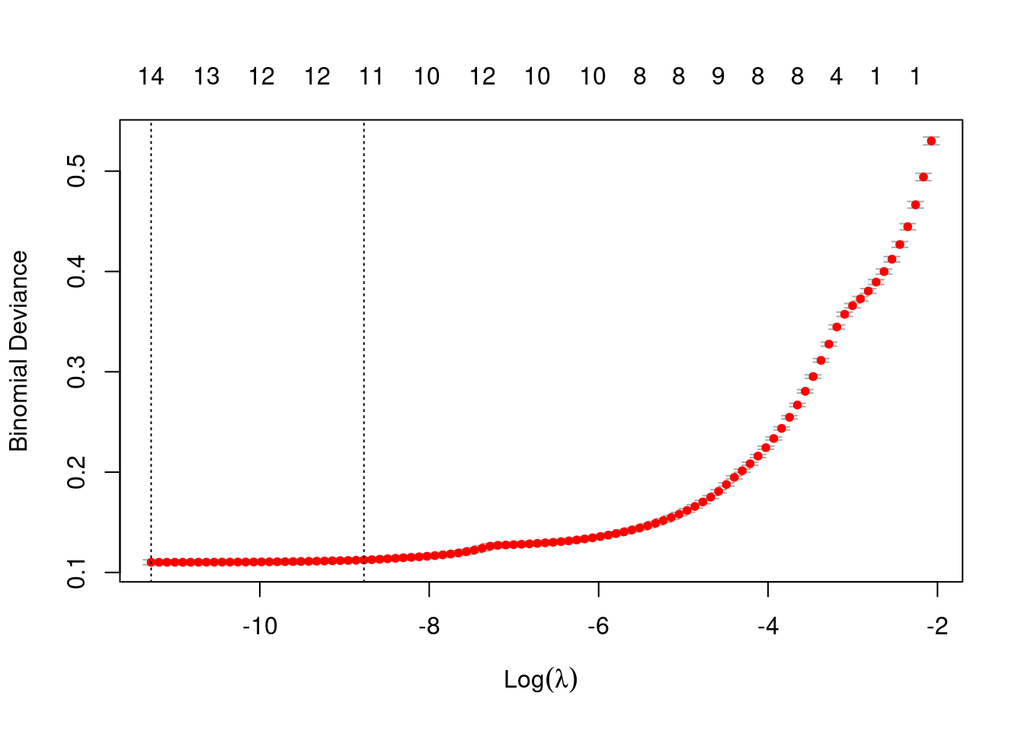

```r
set.seed(1)
cv_lasso<-cv.glmnet(x[train,],y[train],alpha=1,family="binomial",type.measure = "deviance")
plot(cv_lasso)
```

```r
bestlam_lasso<-cv_lasso$lambda.min
bestlam_lasso
```

```
## [1] 1.258939e-05
```

```r
log(bestlam_lasso)
```

```
## [1] -11.28266
```

```r
cv_lasso$lambda.1se
```

```
## [1] 0.0001552079
```

```r
log(cv_lasso$lambda.1se)
```

```
## [1] -8.770745
```

## 4.2 Fit LASSO regression model on training data set using lambda.min

We use the lambda chosen by cross validation i.e. lambda.min. This is the value of λ that gives minimum mean cross-validated error. The other λ saved is lambda.1se, which gives the most regularized model such that error is within one standard error of the minimum. To use that, we only need to replace lambda.min with lambda.1se above.

```r
model_lasso<-glmnet(x[train,],y[train],alpha=1,lambda=bestlam_lasso,family="binomial")
predict(model_lasso,type="coefficients",s=bestlam_lasso)
```

```
## 17 x 1 sparse Matrix of class "dgCMatrix"
##                           1
## (Intercept)   -3.812829e+04
## (Intercept)    .
## age            2.736792e+00
## sum.assured    2.520355e-05
## salary         1.828247e-17
## genderM        4.342274e-01
## smoker_status  7.453209e+00
## compulsory    -5.268431e-02
## yrs_service   -6.482821e-01
## vo2max        -5.071241e-01
## bmi           -9.306307e+00
## var1           1.152789e-01
## var2          -7.640373e-01
## var3           5.052717e+00
## var4           3.738230e+00
## var5           6.638695e-01
## exposure_year -5.425579e-03
```

We see that in this example lambda.min tuning parameter does not shrink any coefficients to zero.

## 4.3 Fit LASSO regression model on training data set using lambda.1se

```r
model_lasso_1se<-glmnet(x[train,],y[train],alpha=1,lambda=cv_lasso$lambda.1se,family="binomial")
predict(model_lasso_1se,type="coefficients",s=cv_lasso$lambda.1se)
```

```
## 17 x 1 sparse Matrix of class "dgCMatrix"
##                           1
## (Intercept)   -2.805482e+04
## (Intercept)    .
## age            1.965153e+00
## sum.assured    2.188653e-05
## salary         2.987745e-18
## genderM        3.140859e-01
## smoker_status  3.188391e+00
## compulsory     .
## yrs_service    .
## vo2max         .
## bmi           -6.296371e+00
## var1           .
## var2           .
## var3           1.166643e+00
## var4           2.840966e+00
## var5           3.804420e-01
## exposure_year -3.094595e-03
```

We see that in this example lambda.1se tuning parameter shrinks some coefficients to zero.

## 4.4 Fit model on training data set using larger lambda

```r
checklambda<-exp(-5)
model_lasso_check<-glmnet(x[train,],y[train],alpha=1,lambda=checklambda,family="binomial")

predict(model_lasso_check,type="coefficients",s=checklambda)
```

```
## 17 x 1 sparse Matrix of class "dgCMatrix"
##                           1
## (Intercept)   -7.576196e+03
## (Intercept)    .
## age            2.501070e-01
## sum.assured    8.671689e-06
## salary         1.123957e-18
## genderM        .
## smoker_status  1.006405e+00
## compulsory     .
## yrs_service    4.455467e-01
## vo2max         .
## bmi            .
## var1           .
## var2           5.400066e-01
## var3          -1.001235e+00
## var4           8.105125e-01
## var5           .
## exposure_year  .
```

We see that in this example LASSO has shrunk many coefficients to zero since we have deliberately chosen a large lambda tuning parameter.

# 5 Assess models’ performance on test set

## 5.1 Metrics for model fitted using lambda.min

```r
assess<-assess.glmnet(model_lasso, newx=x[test,], newy = y[test])
assess
```

```
## $deviance
##        s0
## 0.1183675
## attr(,"measure")
## [1] "Binomial Deviance"
##
## $class
##        s0
## 0.0240761
## attr(,"measure")
## [1] "Misclassification Error"
##
## $auc
## [1] 0.993082
## attr(,"measure")
## [1] "AUC"
##
## $mse
##         s0
## 0.03482559
## attr(,"measure")
## [1] "Mean-Squared Error"
##
## $mae
##         s0
## 0.06981465
## attr(,"measure")
## [1] "Mean Absolute Error"
```

```r
cnf <- confusion.glmnet(model_lasso, newx = x[test, ], newy = y[test])
print(cnf)
```

```
##          True
## Predicted     N    Y Total
##     N     21706  316 22022
##     Y       256 1480  1736
##     Total 21962 1796 23758
##
##  Percent Correct:  0.9759
```

Confusion matrix above predicts if each member of the test data set claims or not based on their probability scores. Threshold used above is 0.5. So if probability score is >0.5 claim is predicted, otherwise no claim predicted.

## 5.2 Metrics for model fitted using lambda.1se

```r
assess_1se<-assess.glmnet(model_lasso_1se, newx=x[test,], newy = y[test])
assess_1se
```

```
## $deviance
##        s0
## 0.1199744
## attr(,"measure")
## [1] "Binomial Deviance"
##
## $class
##         s0
## 0.02487583
## attr(,"measure")
## [1] "Misclassification Error"
##
## $auc
## [1] 0.9929352
## attr(,"measure")
## [1] "AUC"
##
## $mse
##         s0
## 0.03559113
## attr(,"measure")
## [1] "Mean-Squared Error"
##
## $mae
##         s0
## 0.07386506
## attr(,"measure")
## [1] "Mean Absolute Error"
```

```r
cnf_1se <- confusion.glmnet(model_lasso_1se, newx = x[test, ], newy = y[test])
print(cnf_1se)
```

```
##          True
## Predicted     N    Y Total
##     N     21718  347 22065
##     Y       244 1449  1693
##     Total 21962 1796 23758
##
##  Percent Correct:  0.9751
```

## 5.3 Metrics for model fitted using manually chosen lambda

```r
assess_check<-assess.glmnet(model_lasso_check, newx=x[test,], newy = y[test])
assess_check
```

```
## $deviance
##        s0
## 0.1659498
## attr(,"measure")
## [1] "Binomial Deviance"
##
## $class
##         s0
## 0.03388332
## attr(,"measure")
## [1] "Misclassification Error"
##
## $auc
## [1] 0.9910344
## attr(,"measure")
## [1] "AUC"
##
## $mse
##        s0
## 0.0477298
## attr(,"measure")
## [1] "Mean-Squared Error"
##
## $mae
##        s0
## 0.1226998
## attr(,"measure")
## [1] "Mean Absolute Error"
```

```r
cnf_check <- confusion.glmnet(model_lasso_check, newx = x[test, ], newy = y[test])
print(cnf_check)
```

```
##          True
## Predicted     N    Y Total
##     N     21825  668 22493
##     Y       137 1128  1265
##     Total 21962 1796 23758
##
##  Percent Correct:  0.9661
```

## 5.4 Get probabilities for test set using fitted models

To calculate the expected value of claims we use the probabilities generated by the models We then calculate the actual risk cost and compare it to the expected risk cost for the test set using the different lambdas

Using lambda.min

```r
test_predictions<-predict(model_lasso,type="response",s=bestlam_lasso,newx=x[test,])%>%
  as_tibble()

names(test_predictions)[1] <- "probabilty"

test_actuals<-y[test]%>%
  as_tibble()

names(test_actuals)[1] <- "actuals"

test_actuals<-mutate(test_actuals,actuals=ifelse(test_actuals$actuals=="Y",1,0))

test_output<-cbind(x[test,],test_predictions,test_actuals)%>%
  mutate(actual_risk_cost=actuals*sum.assured)%>%
  mutate(expected_risk_cost=probabilty*sum.assured)

A<-sum(test_output$actual_risk_cost)
E<-sum(test_output$expected_risk_cost)
A
```

```
## [1] 256882000
```

```r
E
```

```
## [1] 257440650
```

```r
A/E
```

```
## [1] 0.99783
```

```r
data.table:: fwrite(test_output,paste0(wd,"/test_output.csv"))
```

We then do the same using the model fitted with lambda.1se

```r
test_predictions_1se<-predict(model_lasso_1se,type="response",s=cv_lasso$lambda.1se,newx=x[test,])%>%
  as_tibble()

names(test_predictions_1se)[1] <- "probabilty"

test_actuals<-y[test]%>%
  as_tibble()

names(test_actuals)[1] <- "actuals"

test_actuals<-mutate(test_actuals,actuals=ifelse(test_actuals$actuals=="Y",1,0))

test_output_1se<-cbind(x[test,],test_predictions_1se,test_actuals)%>%
  mutate(actual_risk_cost=actuals*sum.assured)%>%
  mutate(expected_risk_cost=probabilty*sum.assured)

A<-sum(test_output_1se$actual_risk_cost)
E<-sum(test_output_1se$expected_risk_cost)
A
```

```
## [1] 256882000
```

```r
E
```

```
## [1] 257142265
```

```r
A/E
```

```
## [1] 0.9989879
```

```r
data.table:: fwrite(test_output_1se,paste0(wd,"/test_output_lambda_1se.csv"))
```

We then do the same using the model fitted with manually chosen lambda

```r
test_predictions_check<-predict(model_lasso_check,type="response",s=checklambda,newx=x[test,])%>%
  as_tibble()

names(test_predictions_check)[1] <- "probabilty"

test_actuals<-y[test]%>%
  as_tibble()

names(test_actuals)[1] <- "actuals"

test_actuals<-mutate(test_actuals,actuals=ifelse(test_actuals$actuals=="Y",1,0))

test_output_basic<-cbind(x[test,],test_predictions_check,test_actuals)%>%
  mutate(actual_risk_cost=actuals*sum.assured)%>%
  mutate(expected_risk_cost=probabilty*sum.assured)

A<-sum(test_output_basic$actual_risk_cost)
E<-sum(test_output_basic$expected_risk_cost)
A
```

```
## [1] 256882000
```

```r
E
```

```
## [1] 247145718
```

```r
A/E
```

```
## [1] 1.039395
```

```r
data.table:: fwrite(test_output_basic,paste0(wd,"/test_output_larger_lambda.csv"))
```

We can see that the model fitted using lambda.min selects all of the 15 variables. This lambda coefficient minimizes the deviance function.

The model fitted using lambda.1se ensures that the deviance function is within one standard error of the minimum.Some coefficients are shrunk to zero improving interpretability of the model.

For the last model we deliberately chose the lambda tuning parameter to be high and as a result fewer variables are selected. This model is obviously easier to interpret however the deviance function is higher.

```r
end_time=Sys.time()

tot_time=end_time-start_time
tot_time
```

```
## Time difference of 7.88375 mins
```

# 6 Key considerations

- Understanding the business problem, for example
  - To support mortality experience analysis for reserving?
  - To support underwriting team when deciding what members require additional underwriting?
  - To support pricing team?
- Ethics and compliance
  - Engage early with compliance team to ensure that required data can be collected in accordance with rules and regulations
  - Is there risk that our model could result in exclusion of certain groups from coverage?
- Data quality and volume
  - May depend on the business problem
  - Will we have the variables chosen by the model for future business?
- Data architecture
  - For larger data sets (e.g. millions of rows, hundreds of variables) run time for glmnet may be too slow so other options may need to be considered such as Spark and H2O
  - Spark: https://therinspark.com/intro.html
  - H2O: https://docs.h2o.ai/h2o/latest-stable/h2o-docs/data-science/glm.html
- Project structure
  - CRISP DM: https://www.datascience-pm.com/crisp-dm-2/
- Communication
  - Rmarkdown: https://bookdown.org/yihui/rmarkdown/
  - ggplot: https://ggplot2.tidyverse.org/
  - Shiny: https://shiny.rstudio.com/
- Interpretability and accuracy

# 7 Further reading

- Logistic Regression for Insured Mortality Experience Studies:
  - SOA: https://www.soa.org/globalassets/assets/files/resources/essays-monographs/2014-living-to-100/mono-li14-2a-zhu.pdf
- LASSO modeling for mortality:
  - Gary Venter: http://www.garyventer.com/wp-content/uploads/2018/08/Venter-2018-Regularized-Age-Period-Cohort-Modeling-of-Opioid-Mortality-Rates-Preprint.pdf
- glmnet package: https://cran.r-project.org/web/packages/glmnet/vignettes/glmnet.pdf